# Лабораторная №1. Выявление характерной лексики в описаниях российских ресторанных бизнесов в зависимости от их ценовой категории

Виктория Болотова

17 10 2021

# Аналитическая задача, характеристика данных

Здравствуйте! :)

В этой лабораторной работе я использую данные с Kaggle примерно о 2740 ритейлеров, работающих в России (https://www.kaggle.com/pavelkunitsyn/russian-retail). Первоначальные данные включают в себя информацию о компаниях с различными специализациями бизнеса, **но я решила сфокусироваться на данных компаний, представляющих собой кафе/рестораны/столовые/кофейни/пабы**. Страна происхождения ресторанных бизнесов варьируется, преимущественно из России.

В этих данных есть привлекающая внимание колонка - **“description”**, в которой содержится *всестороннее описание бизнеса*. Я проверила, что описание бизнесов точь-в-точь совпадает с тем, что у самих бизнесов написано на их сайтах, то есть мы можем доверять этим данным.

Содержание колонки “desciption” у Додо Пиццы:

*“Обычно люди приходят в Додо Пиццу, чтобы просто поесть. Наши промоутеры раздают листовки про кусочек пиццы за двадцать рублей или ещё что-то выгодное. Мы делаем это как первый шаг, чтобы познакомиться. Но для нас Додо — не только пицца. Это и пицца тоже, но в первую очередь это большое дело, которое вдохновляет нас, заставляет каждое утро просыпаться и с интересом продолжать работу. В чём же наш интерес? Сейчас расскажем.Почему мы так хотим познакомиться? Потому что дальше пицца делает всё сама. Люди видят, что она вкусная, и возвращаются снова. Нам главное первый раз это показать. Вообще пицца — очень простая штука, её сложно испортить. Достаточно хороших ингредиентов и правильного теста. Это конструктор, если детали качественные, то и результат будет в порядке. Вот они, наши детали: Кто угодно может сделать вкусную пиццу. А шеф-повар итальянского ресторана сделает и вовсе шедевр. Он молодец. Но представьте, что вам нужно сделать вкусную пиццу в сотнях пиццерий, за сотни километров друг от друга. Это наш случай, у нас их вон уже сколько: Пицца должна быть вкусной и везде одинаковой. Пиццерии должны быть одинаково уютными, кассиры неизменно приветливыми, а курьеры — расторопными. И это как раз сложно. Но мы умеем!”*

Именно такой текст размещен на офицальном сайте Додо.

**Мой исследовательский интерес** к этим данным заключен в желании проанализировать, как **характерная лексика описания бизнесов** (как бизнесы сами себя представляют для потенциальных клиентов) **меняется в зависимости от ценновой категории бизнеса** (описательный график будет чуть позже). Для меня как социолога эта задача интересна, поскольку бизнесы в описаниях самих себя ставят **цель найти отклик от своей целевой аудитории**, а не просто презентовать себя. А поскольку российское общество достаточно сильно стратицифированно, то бизнесы, в зависимости от своей ценовой категории, стараются убедить свою целевую аудиторию, что они **смогут удовлетворить их нужды, пожелания**. В свою очередь, потребительское поведение и желания людей на самом деле значительно **определяются их социальным классом**, как писал Пьер Бурдье.

**Потребление** является одной из практик, с помощью которых **люди проявляют принадлежность к своему социальному классу** или к классу, к которому они хотели бы принадлежать. Таким образом, я предполагаю, что мы с Вами увидим, как **рестораны и кафе “продают” опыт такой принадлежности** - возникает **“экономика впечатлений”** (Joseph Pine, James Gilmore 1998).

- Размер всего корпуса после препроцессинга: 31765 слов.

# Препроцессинг данных

## Загружаем необходимые библиотеки и считываем данные

```r
library(readr)
library(dplyr)
library(ggplot2)
library(tidytext)
library(stringr)
library(tidyr)
library(tidylo) # для подсчёта weighted log-odds
retail <- read_csv("russian_retail.csv")
```

## Отфильтровываем данные и отбираем нужные переменные

```r
cafe <- retail %>%
  filter(retail$domain == 'Кафе, ресторан') %>%
  select(name, price_category, description)
nrow(cafe)
```

```
## [1] 343
```

**Удаляем пропущенные значения**

```r
cafe <- na.omit(cafe)
nrow(cafe)
```

```
## [1] 342
```

```r
glimpse(cafe) #посмотрим на наши данные
```

```
## Rows: 342
## Columns: 3
## $ name           <chr> "13 Rules", "33 Пингвина", "Auntie Annes", "Baggins Co…
## $ price_category <chr> "Средний", "Средний; Выше среднего", "Средний", "Средн…
## $ description    <chr> "Компания 13 Rules основана в 2012 году Алексеем Омель…
```

Количество строк уменьшилось на единицу - то есть мы потеряли информацию только об одном кафе/ресторане.

**Визуализация**

Давайте посмотрим на процентное отношения количества ресторанных бизнесов в зависимости от ценовой категории:

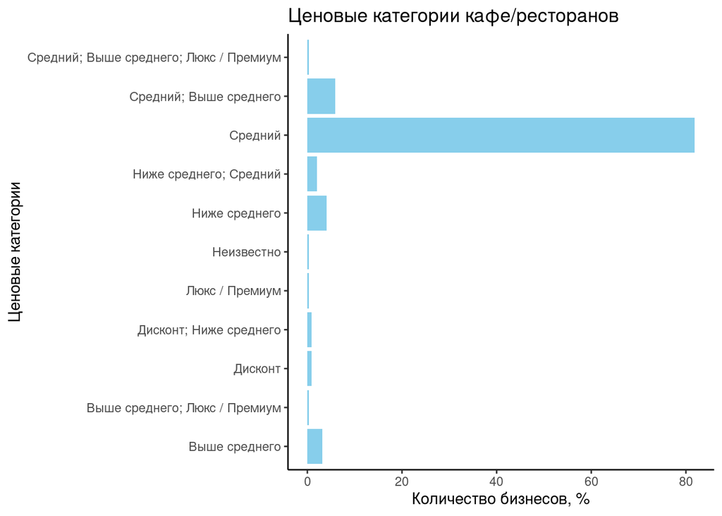

```r
ggplot() + geom_bar(data = cafe, fill = "skyblue", aes(x = as.factor(price_category), y=..count../sum(..count..)*100)) + labs(y="Количество бизнесов, %", x="Ценовые категории", title = "Ценовые категории кафе/ресторанов") + coord_flip() + theme_classic()
```

Больше всего представлен ресторанный бизнес средней ценовой категории. Нашим фокусным корпусом будут слова из описаний бизнесов, у которых ценовая категория:

- ‘Средний; Выше среднего; Люкс / Премиум’
- ‘Выше среднего’
- ‘Выше среднего; Люкс / Премиум’
- ‘Люкс / Премиум’
- ‘Средний; Выше среднего’

## Чистка и нормализация текста

В описаниях бизнесов содержатся много цифр, поэтому давайте отчистим текст от них, так как важной информации они не представляют для данной аналитической задачи.

**Избавляемся от цифр**

Избавляемся от цифр и сохраняем отчищенные от цифр описания в новую колонку `clean_desciption`

```r
cafe$clean_desciption <- str_replace_all(cafe$description, "[0-9]+", " ")
glimpse(cafe)
```

```
## Rows: 342
## Columns: 4
## $ name             <chr> "13 Rules", "33 Пингвина", "Auntie Annes", "Baggins …
## $ price_category   <chr> "Средний", "Средний; Выше среднего", "Средний", "Сре…
## $ description      <chr> "Компания 13 Rules основана в 2012 году Алексеем Оме…
## $ clean_desciption <chr> "Компания   Rules основана в   году Алексеем Омельче…
```

Лемматизация на мой взгляд необходима и её нужно провести до токенизации.

**Лемматизация**

```r
cafe$lem <- system2("mystem", c("-d", "-l", "-c"), input = cafe$clean_desciption, stdout = TRUE)
glimpse(cafe)
```

```
## Rows: 342
## Columns: 5
## $ name             <chr> "13 Rules", "33 Пингвина", "Auntie Annes", "Baggins …
## $ price_category   <chr> "Средний", "Средний; Выше среднего", "Средний", "Сре…
## $ description      <chr> "Компания 13 Rules основана в 2012 году Алексеем Оме…
## $ clean_desciption <chr> "Компания   Rules основана в   году Алексеем Омельче…
## $ lem              <chr> "{компания}   {Rules??} {основывать} {в}   {год} {ал…
```

Это лабороторная работа будет базироваться на основе текстового анализа описаний *342* бизнесов, специализирующехся в сфере ресторанов, кафе, пабов и т.д.

Теперь можно смело приступать к токенизации текста на слова.

**Токенизация**

```r
cafe_tokens <- cafe %>% unnest_tokens(word, lem)
glimpse(cafe_tokens)
```

```
## Rows: 38,405
## Columns: 5
## $ name             <chr> "13 Rules", "13 Rules", "13 Rules", "13 Rules", "13 …
## $ price_category   <chr> "Средний", "Средний", "Средний", "Средний", "Средний…
## $ description      <chr> "Компания 13 Rules основана в 2012 году Алексеем Оме…
## $ clean_desciption <chr> "Компания   Rules основана в   году Алексеем Омельче…
## $ word             <chr> "компания", "rules", "основывать", "в", "год", "алек…
```

```r
nrow(cafe_tokens)
```

```
## [1] 38405
```

На этом этапе объем всего корпуса: 38405 слов

**Ограничение лексикона**

```r
stop_lem <- cafe_tokens %>%
    count(word, name) %>%
    group_by(word) %>%
    filter(n() < 4)
nrow(stop_lem)
```

```
## [1] 5458
```

Давайте теперь посмотрим от чего мы избавились:

```r
stop_lem %>% arrange(desc(n)) %>% head(10)
```

```
## # A tibble: 10 x 3
## # Groups:   word [10]
##    word      name                 n
##    <chr>     <chr>            <int>
##  1 барс      Сковорода           14
##  2 donuts    Dunkin Donuts       12
##  3 dunkin    Dunkin Donuts       12
##  4 maki      MAKI MAKI           10
##  5 people    PEOPLE’S            10
##  6 доминос   Domino’s pizza      10
##  7 патио     IL Патио            10
##  8 татарский Татарские пироги    10
##  9 чайхон    Чайхона №1          10
## 10 comedy    Comedy Cafe          9
```

- Из таблицы мы видим, что мы как раз избавились от слов, которые отражали название бизнеса, например:
  - слова *donuts* и *dankin* у компании *Dunkin Donuts*
  - слово *maki* у компании *MAKI MAKI*
  - слово *people* у компании *PEOPLE’S*
  - и т.д.
- Почему я не ограничила слова, которые встречаются не более чем в одном описании бизнеса:
  - Дело в том, что, как я поняла в ходе вычитки описаний и поиска слов, некоторые отдельные бизнесы являются объединениями, поэтому их описания совпадают. Но в таких объединений не больше 4 кафе/ресторанов.

Проводим антиджоин таблицы `cafe_tokens` с таблицей `stop_lem`:

```r
clean_tokens <- cafe_tokens %>% anti_join(stop_lem)
nrow(clean_tokens)
```

```
## [1] 31765
```

```r
nrow(cafe_tokens)
```

```
## [1] 38405
```

Конечный объем корпуса: 31765 слов. Я решила не исключать стоп-слова, поскольку мне кажется это приведет к потере многих на самом деле важных для моей задачи слов, например, обращений (Вы и т.д.) или местоимений (мы).

Основание выделение фокусного коруса - ценовая категория кафе/ресторана выше среднего и люкс/премиум

```r
corpus <- clean_tokens %>%
  mutate(corpus = ifelse(price_category %in% c('Выше среднего', 'Выше среднего; Люкс / Премиум',    'Люкс / Премиум', 'Средний; Выше среднего', 'Средний; Выше среднего; Люкс / Премиум'), 'focus', 'reference'))
glimpse(corpus)
```

```
## Rows: 31,765
## Columns: 6
## $ name             <chr> "13 Rules", "13 Rules", "13 Rules", "13 Rules", "13 …
## $ price_category   <chr> "Средний", "Средний", "Средний", "Средний", "Средний…
## $ description      <chr> "Компания 13 Rules основана в 2012 году Алексеем Оме…
## $ clean_desciption <chr> "Компания   Rules основана в   году Алексеем Омельче…
## $ word             <chr> "компания", "основывать", "в", "год", "алексей", "за…
## $ corpus           <chr> "reference", "reference", "reference", "reference", …
```

Для начала давайте посмотрим на простую частотность.

```r
corpus_freq <- corpus %>%
    group_by(corpus) %>%
    count(word) %>%
    spread(corpus, n, fill=0) %>%
    arrange(desc(focus + reference))
corpus_freq
```

```
## # A tibble: 1,280 x 3
##    word     focus reference
##    <chr>    <dbl>     <dbl>
##  1 и          183      1658
##  2 в          172      1459
##  3 на          45       497
##  4 с           46       431
##  5 сеть        38       424
##  6 ресторан    46       405
##  7 мы          54       393
##  8 год         34       350
##  9 это         31       311
## 10 наш         22       300
## # … with 1,270 more rows
```

Все в порядке, можно приступать к следующему шагу.

# Выделение характерной лексики

## Простое отношение нормализованной частотности слов (по simple maths Адама Килгариффа)

**При константе 1**

```r
cafe_ipm_n1 <- corpus_freq %>%
  mutate(f.ipm = (focus+1)/sum(focus+1)*10000, r.ipm = (reference+1)/sum(reference+1)*10000) %>%     mutate(sm = f.ipm/r.ipm) %>% arrange(desc(sm))
cafe_ipm_n1
```

```
## # A tibble: 1,280 x 6
##    word      focus reference f.ipm r.ipm    sm
##    <chr>     <dbl>     <dbl> <dbl> <dbl> <dbl>
##  1 зерно         9         2 22.5  1.00  22.4
##  2 лондон        4         1 11.3  0.669 16.8
##  3 добавлять     3         1  9.01 0.669 13.5
##  4 новость       3         2  9.01 1.00   8.97
##  5 йорк          4         3 11.3  1.34   8.41
##  6 кальянный     4         3 11.3  1.34   8.41
##  7 казахстан     5         4 13.5  1.67   8.08
##  8 обжарка       5         4 13.5  1.67   8.08
##  9 мегаполис     7         6 18.0  2.34   7.69
## 10 мороженое    11        11 27.0  4.02   6.73
## # … with 1,270 more rows
```

**При константе 10**

```r
cafe_ipm_n10 <- corpus_freq %>%
  mutate(f.ipm = (focus+10)/sum(focus+10)*10000,
         r.ipm = (reference+10)/sum(reference+10)*10000) %>%
  mutate(sm = f.ipm/r.ipm) %>% arrange(desc(sm))
cafe_ipm_n10
```

```
## # A tibble: 1,280 x 6
##    word      focus reference f.ipm r.ipm    sm
##    <chr>     <dbl>     <dbl> <dbl> <dbl> <dbl>
##  1 зерно         9         2 11.9   2.90  4.11
##  2 лондон        4         1  8.77  2.66  3.30
##  3 добавлять     3         1  8.15  2.66  3.07
##  4 новость       3         2  8.15  2.90  2.81
##  5 йорк          4         3  8.77  3.14  2.79
##  6 кальянный     4         3  8.77  3.14  2.79
##  7 казахстан     5         4  9.40  3.38  2.78
##  8 обжарка       5         4  9.40  3.38  2.78
##  9 мегаполис     7         6 10.7   3.86  2.76
## 10 мороженое    11        11 13.2   5.07  2.59
## # … with 1,270 more rows
```

При изменении константы на 10 список характерных слов не изменятся.

**При константе 100**

```r
cafe_ipm_n100 <- corpus_freq %>%
  mutate(f.ipm = (focus+100)/sum(focus+100)*10000,
         r.ipm = (reference+100)/sum(reference+100)*10000) %>%
  mutate(sm = f.ipm/r.ipm) %>% arrange(desc(sm))
cafe_ipm_n100
```

```
## # A tibble: 1,280 x 6
##    word      focus reference f.ipm r.ipm    sm
##    <chr>     <dbl>     <dbl> <dbl> <dbl> <dbl>
##  1 зерно         9         2  8.31  6.51  1.28
##  2 лондон        4         1  7.93  6.45  1.23
##  3 добавлять     3         1  7.85  6.45  1.22
##  4 новость       3         2  7.85  6.51  1.21
##  5 йорк          4         3  7.93  6.58  1.21
##  6 кальянный     4         3  7.93  6.58  1.21
##  7 казахстан     5         4  8.01  6.64  1.21
##  8 обжарка       5         4  8.01  6.64  1.21
##  9 мегаполис     7         6  8.16  6.77  1.21
## 10 арабика       3         3  7.85  6.58  1.19
## # … with 1,270 more rows
```

А вот изменение константы с 10 до 100 выводит слово `арабика` на 10 место, в то время как остальные слова остались на своих местах.

Выводы по частотной лексике, используя метод simple maths Адама Килгариффа:

- Мы видим целых три слова, связанных с тематикой кофе в топ-10: слова `зерно`, `обжарка`, `арабика` указывают на то, что кофейни или же кафе, специлизирующиеся на кофе, чаще ориентируются на посетителей, которые готовы платить больше, чем среднестатистический российский гражданин.
- Слова `Лондон`, `Йорк` (Нью-Йорк), `Казахстан` тоже попавшие в топ-10 дают нам возможность предположить, что среди ресторанов и кафе, у которых ценовая категория выше среднего, страна происхождения бизнеса чаще всего является Велибритания или США (проверила по поиску в данных). А Казахстан попал в топ-10 так как компании, ориентирующееся на ценовую категорию выше среднего, предпочитают открывать свои сети в этом государстве - о чем и сообщают нам в своих описаниях (тоже проверила).
- Ресторанные бизнеса, чья ценовая категория выше среднего, чаще имееют кальянную зону.

Что-ж, давайте посмотрим какие списки наиболее характерных слов мы получим, используя другие методы.

## Отношение правдоподобия (Dunning log-likelihood)

Определим функцию для вычисления Dunning log-likelihood (G^2):

```r
g2 = function(a, b) {
  c = sum(a)
  d = sum(b)
  E1 = c * ((a + b) / (c + d))
  E2 = d * ((a + b) / (c + d))
  return(2*((a*log(a/E1+1e-7)) + (b*log(b/E2+1e-7))))
}
```

Применим функцию g2, определенную выше, для вычисления log-likelihood и отсортируем результаты по значению g2.

```r
cafe_ll <- corpus_freq %>%
    mutate(g2 = g2(focus, reference)) %>%
    arrange(desc(g2))

cafe_ll
```

```
## # A tibble: 1,280 x 4
##    word         focus reference    g2
##    <chr>        <dbl>     <dbl> <dbl>
##  1 s               22        34  33.6
##  2 зерно            9         2  31.5
##  3 мороженое       11        11  22.6
##  4 американский    11        16  17.6
##  5 мегаполис        7         6  15.6
##  6 лондон           4         1  13.7
##  7 грузинский      10        18  13.4
##  8 здесь           10        19  12.8
##  9 выпечка          0        60  12.6
## 10 казахстан        5         4  11.6
## # … with 1,270 more rows
```

Непонятное s вылезло на вершину нашего частотного списка, но остальные слова вполне себе подходящие для анализа.

- Только одно слово из тематики кофе попало в топ-10 списка наиболее характерных слов по методу log-likelihood: `зерно` (`обжарка` на 11 месте)
- В топ-10 есть такие слова, как `американский`, `лондон`, `грузинский`, `казахстан`. Причину появления Казахстана и Лондона мы уже выяснили. `американский` появляется в контексте кухни ресторана и концепии всего бизнеса, как и `грузинский` (например, у таких заведений, как “Есть Хинкали & Пить Вино”, “Грузинские каникулы” и т.д.)
- Стоит обратить внимание на слово `выпечка`. Оно встречается 0 раз в фокусном корпусе и целых 60 раз в референсном. В целом это ожидаемый результат, поскольку очевидно, что выпечка стоит недорого и при этом это сытно, поэтому навряд ли кафе и рестораны ценовой категорией выше среднего будут иметь у себя в меню много выпечки. Ещё одна причина почему мы увидели слово `выпечка` может заключаться в том, что люди с достатком чаще следят за фигурой и своим здоровьем, а мучные изделия предательски портят фигуру, поэтому рестораны и кафе высокой ценовой категорией, ориентируясь на свою целевую аудиторию, не включают в меню выпечку. Кроме того, люди разных социальных классов ходят в рестораны/кафе, удовлятворяю разные нужды и желания. Люди рабочего класса просто хотят поесть и выйти сытыми из заведения, в то время как люди среднего класса и выше хотят показать себя и получить новые эмоции, впечатления, поэтому их выпечкой не удовлетворить.

Поговорим об используемом методе **log-likelihood**

- Этот метод привел нас к топ-10 списку наиболее характерных слов, которые довольно-таки часто встречаются как и в изучаемом (focus), так и в контрастном (reference) корпусе (11 раз, 16 раз, 10, 18 и даже 60). В то время как подход simple maths (при константе 100) привел нас к списку слов, в котором частотность ни одного слова в топ-10 не превышает 9.
- Тут мы и столкнулись с проблемой **log-likelihood** - занижение степени различия по менее частотным словам. Таким образом, этот подход завысил степень различия по часто встречающемся словам, поэтому мы и обнаруживаем частотные слова на вершине наиболее характерной лексики.

Давайте обратимся к другим методам.

## Pointwise mutual information (PMI)

Pointwise mutual information — PMI = log2(p(x,y)/p(x)p(y))

Или же: PMI = log2(p(x|y)/p(x)), где

- p(x|y) — вероятность встретить слово x в описании кафе/ресторанов, у которых ценовая категория выше среднего или люкс/премиум p(x|кафе с высокой ценовой категорией).
- p(x) — вероятность встретить слова во всех описаниях всех кафе и ресторанов (в том числе и в описаниях кафе/ресторанов с ценовой категорией выше среднего/люкс/премиум).

Создадим колонки с двумя нужными нам для вычисления PMI вероятностями.

```r
cafe_p <- corpus_freq %>%
    mutate(p.x_y = focus/sum(focus), p.x = (focus+reference)/(sum(focus)+sum(reference)))
cafe_p
```

```
## # A tibble: 1,280 x 5
##    word     focus reference   p.x_y    p.x
##    <chr>    <dbl>     <dbl>   <dbl>  <dbl>
##  1 и          183      1658 0.0579  0.0580
##  2 в          172      1459 0.0544  0.0513
##  3 на          45       497 0.0142  0.0171
##  4 с           46       431 0.0146  0.0150
##  5 сеть        38       424 0.0120  0.0145
##  6 ресторан    46       405 0.0146  0.0142
##  7 мы          54       393 0.0171  0.0141
##  8 год         34       350 0.0108  0.0121
##  9 это         31       311 0.00981 0.0108
## 10 наш         22       300 0.00696 0.0101
## # … with 1,270 more rows
```

Создадим и вычислим колонку `focus.pmi` и отсортируем данные по ней.

```r
cafe_pmi <- cafe_p %>%
    mutate(focus.pmi = log2(p.x_y/p.x)) %>%
    arrange(desc(focus.pmi))
cafe_pmi
```

```
## # A tibble: 1,280 x 6
##    word      focus reference    p.x_y      p.x focus.pmi
##    <chr>     <dbl>     <dbl>    <dbl>    <dbl>     <dbl>
##  1 зерно         9         2 0.00285  0.000346      3.04
##  2 лондон        4         1 0.00127  0.000157      3.01
##  3 добавлять     3         1 0.000949 0.000126      2.91
##  4 новость       3         2 0.000949 0.000157      2.59
##  5 йорк          4         3 0.00127  0.000220      2.52
##  6 кальянный     4         3 0.00127  0.000220      2.52
##  7 казахстан     5         4 0.00158  0.000283      2.48
##  8 обжарка       5         4 0.00158  0.000283      2.48
##  9 мегаполис     7         6 0.00222  0.000409      2.44
## 10 мороженое    11        11 0.00348  0.000693      2.33
## # … with 1,270 more rows
```

Результирующий список топ-10 наиболее характерной лексики для фокусного корпуса индентичен списку, полученному с помощью подхода simple maths, когда константа равнялась 1 и 10. Однако некоторые из следующих 10 слов (с 11 до 20) отличаются порядком от того, что нам предложил подход simple maths.

Метод PMI славится и не очень приятными моментами, как завышение степени различия по редким словам. Например, слово `добавлять` встречается 3 раза в фокусном корусе и только 1 в референсном, но при этом оно занимает почётное бронзовое место в списке наиболее характерной лексики. При этот это слово во всех четырех употреблениях несет разный контекстный смысл (проверила).

Частотность следующих топ-слов с 11 до 20 не превышает 5. Например, слово `безупречный` встречается в обоих корпусах по два раза. Интересно ещё то, что абсолютно все слова с 11 до 20 встречаются в обоих корпусах индентичное количество раз. Дело в том, что PMI чувствителен не просто к редким словам, но высоко информативным относительно друг друга словам. Именно поэтому мы наблюдаем такую симметрию.

Наш последний метод на сегодня - weighted log-odds.

## Weighted log-odds

```r
cafe_counts_lo <- corpus %>% count(corpus, word, sort=TRUE)
cafe_counts_lo
```

```
## # A tibble: 2,057 x 3
##    corpus    word         n
##    <chr>     <chr>    <int>
##  1 reference и         1658
##  2 reference в         1459
##  3 reference на         497
##  4 reference с          431
##  5 reference сеть       424
##  6 reference ресторан   405
##  7 reference мы         393
##  8 reference год        350
##  9 reference это        311
## 10 reference наш        300
## # … with 2,047 more rows
```

Добавим колонку со значением weighted_log_odds:

```r
cafe_lo <- cafe_counts_lo %>%
    bind_log_odds(corpus, word, n)
cafe_lo
```

```
## # A tibble: 2,057 x 4
##    corpus    word         n log_odds_weighted
##    <chr>     <chr>    <int>             <dbl>
##  1 reference и         1658            -2.00
##  2 reference в         1459            -2.01
##  3 reference на         497            -0.822
##  4 reference с          431            -0.935
##  5 reference сеть       424            -0.747
##  6 reference ресторан   405            -0.976
##  7 reference мы         393            -1.20
##  8 reference год        350            -0.749
##  9 reference это        311            -0.728
## 10 reference наш        300            -0.480
## # … with 2,047 more rows
```

Выберем наиболее характерные слова для описаний кафе/ресторанов, чья ценовая категория выше среднего или люкс/премиум - то есть наш фокусный корпус:

```r
cafe_lo_focus <- cafe_lo %>% filter(corpus == "focus") %>%
    arrange(-log_odds_weighted)
cafe_lo_focus
```

```
## # A tibble: 777 x 4
##    corpus word             n log_odds_weighted
##    <chr>  <chr>        <int>             <dbl>
##  1 focus  в              172              3.07
##  2 focus  и              183              3.06
##  3 focus  s               22              2.27
##  4 focus  зерно            9              2.04
##  5 focus  который         38              1.91
##  6 focus  мы              54              1.82
##  7 focus  мороженое       11              1.81
##  8 focus  американский    11              1.64
##  9 focus  большой         16              1.50
## 10 focus  мегаполис        7              1.49
## # … with 767 more rows
```

Используя метод *weighted_log_odds* мы получили список слов, в которых обнаруживаются “стоп-слова”:

- и
- в
- который
- мы

Для меня тут интересно местоимение `мы`. Наверное, мы можем предположить, что бизнесы ценовой категорией выше среднего, более склоны подчеркивать важность команды сотрудников кафе/ресторана и убеждать свою целевую аудиторию, что он (бизнес) позаботился о составе команды, которая напрямую влияет на качество времяпрепровождения посетителей в их заведении.

Также, мы видим слова, которые уже появлялись в топ-10 наиболее характерной лексики, когда мы использовали другие методы:

- зерно (simple maths & log-likelihood & PMI)
- мороженое (simple maths - при константах 1 и 10 & log-likelihood & PMI)
- американский (log-likelihood)
- мегаполис (simple maths & log-likelihood & PMI)

Новое не “стоп-слово” слово в топ-10:

- большой (контекст: большой ассортимент, большой угольный гриль, большой кирпичный мангал, самой большой сетью)

О самом методе *weighted_log_odds*:

- Мы видим наибольшее совпадение слов, полученных с помощью *weighted_log_odds*, с методом *log-likelihood*. Учитывая что подход log-likelihood более чувствителен к частотным словам, вполне ожидаемо получить такое совпадение, поскольку weighted_log_odds показывает еще более частотные слова, чем log-likelihood.
- Действительно, *weighted_log_odds* выводит нам в топ-10 наиболее харатктерной лексики очень частотные слова - даже стоп-слова. Такой эффект возможен из-за того, что метод weighted log odds предпологает, что мы можем быть более уверенными в словах как в показателях специфичной лексики только когда слова встречаются очень много раз (как стоп-слова, например) и менее уверенными в словах, которых встречались только несколько раз.

Давайте посмотрим на референсный корпус:

```r
cafe_lo_reference <- cafe_lo %>% filter(corpus == "reference") %>%
    arrange(-log_odds_weighted)
cafe_lo_reference
```

```
## # A tibble: 1,280 x 4
##    corpus    word               n log_odds_weighted
##    <chr>     <chr>          <int>             <dbl>
##  1 reference выпечка           60              3.23
##  2 reference ваш               42              2.70
##  3 reference пирог             39              2.60
##  4 reference изделие           32              2.35
##  5 reference фуд               31              2.32
##  6 reference московский        29              2.24
##  7 reference сотрудник         28              2.20
##  8 reference дом               24              2.04
##  9 reference запускать         24              2.04
## 10 reference сотрудничество    24              2.04
## # … with 1,270 more rows
```

- Мы видим четыре слова из топ-10, связанных с не очень правильным питанием: `выпечка`, `пирог`, `фуд` (фаст-фуд изначально - я проверила) и `изделия` (контекст: кондитерские изделия, хлебобулочные изделия)
- Частое употребление местоимения `ваш`
- Целых два однокоренных слова: `сотрудник`, `сотрудничество`
- Опять же в топ-10 наиболее характерной лексики попали слова с высокой частотностью (60, 42). Метрика log_odds_weighted уменьшается по мере уменьшения частотности слов.

# Заключение о специфической лексике фокусного корпуса

- Кафе, специлизирующееся на кофе, представляют собой в среднем более высокую ценовую категорию бизнеса.
- Среди ресторанов и кафе, у которых ценовая категория выше среднего, страна происхождения бизнеса чаще всего является Велибритания или США. Кроме того, компании, ориентирующееся на ценовую категорию выше среднего, предпочитают расширять свой бизнес в Казахстане.
- Рестораны и кафе, имеющие ценовую категорию выше среднего, чаще (по сравнению с ресторанами ценовой категорией средней и ниже средней) представляют собой грузинские и американские заведения (имеется в виду кухня и концепция места).
- Рестораны, кафе, столовые и т.д., у которых ценовая категория **средняя или ниже среднего**, намного более вероятно будут предлагать посетителям различные хлебобулочные и кондитерские изделия, в сравнении с фокусным корпусом.
- Рестораны и кафе, имеющие ценовую категорию выше среднего, часто употребляют местоимения `мы` в своих описаниях. Возможно, так они хотят подчеркнуть тщательный отбор людей в команду и в целом серьезное отношение к тем, кто будет “предоставлять сервис” посетителям, а отличный состав команды гарантирует приятное времяпрепровождения во всех аспектах. В то же время, заведения, ценовой категорией средней или ниже среднего, часто употребляют слово `сотрудник` в своих описаниях. Вероятно, бизнесы, в зависимости от их ценовой категории, по-разному возлагают обязанности, ответственность и при этом “приписывают” заслуги. Рестораны и кафе, имеющие ценовую категорию выше среднего, рассматривают всех сотрудников как единое целое - команду, поэтому используют `мы` в описаниях, в то время как бизнесы, представляющие референсный корпус, склоны возлагать обязанности на каждого отдельного сотрудника и, возможно, не экстраполировать результаты отдельных людей на всю команду.
- Рестораны и кафе, имеющие ценовую категорию выше среднего, чаще готовы предложить мороженое своим посетителям, в сравнении с референсным корпусом.

Вот и всё, надеюсь, Вам было интересно читать мою работу :)